# Projekt ANOVA - BMI

Jakub Anczyk

2023-11-16

### Wstęp

Celem analizy będzie sprawdzenie, czy wiek i lokalizacja ubezpieczonego mają wpływ na wskaźnik BMI, co może mieć kluczowe znaczenie dla ubezpieczyciela w procesie kształtowania polisy, jej wyceny lub ogólnej oceny ryzyka ubezpieczeniowego. W analizie wzięte pod uwagę zostaną wyłącznie osoby w przedziale wiekowym 20-30 lat.

```r
data_raw <- read.csv("insurance.csv")
summary(data_raw)
```

```
##       age            sex                 bmi           children
##  Min.   :18.00   Length:1331        Min.   :15.96   Min.   :0.000
##  1st Qu.:26.50   Class :character   1st Qu.:26.22   1st Qu.:0.000
##  Median :39.00   Mode  :character   Median :30.30   Median :1.000
##  Mean   :39.18                      Mean   :30.62   Mean   :1.093
##  3rd Qu.:51.00                      3rd Qu.:34.64   3rd Qu.:2.000
##  Max.   :64.00                      Max.   :53.13   Max.   :5.000
##     smoker             region             charges
##  Length:1331        Length:1331        Min.   : 1122
##  Class :character   Class :character   1st Qu.: 4729
##  Mode  :character   Mode  :character   Median : 9305
##                                        Mean   :13234
##                                        3rd Qu.:16622
##                                        Max.   :63770
```

### Dane

- **age**: zmienna liczbowa oznaczjąca wiek głównego beneficjenta,
- **sex**: zmienna oznaczająca płeć ubezpieczonego (kobieta lub mężczyzna),
- **bmi**: wskaźnik masy ciała, umożliwiający zrozumienie relacji wagi ciała (w kilogramach) do wzrostu (w metrach). Jest to w miarę obiektywny (choć z pewnością nie idealny) wskaźnik masy ciała obliczany za pomocą następującego wzoru: $BMI = \frac{kg}{m^2}$ ,
- **children**: liczba dzieci objętych ubezpieczeniem zdrowotnym lub inaczej liczba osób na utrzymaniu,
- **smoker**: zmienna oznaczająca, czy ubezpieczony jest osobą palącą lub nie,
- **region**: obszar zamieszkania beneficjenta w USA, północny wschód, południowy wschód, południowy zachód, północny zachód,
- **charges**: indywidualne koszty medyczne rozliczane przez ubezpieczenie zdrowotne,

W pierwszym kroku przygotowuję dane dla dalszej analizy i zawężam obserwacje do interesującego nas zakresu wieku 20-30 lat a następnie zamieniam tę zmienną na faktor.

```r
data <- data_raw %>%
  mutate(charges = as.double(charges)) %>%
  mutate(sex = as.factor(sex),
         region = as.factor(region)) %>%
  filter(age >= 20 & age <= 30) %>%
  select(-c(children, smoker, sex)) %>%
  mutate(age = as.factor(age))

summary(data)
```

```
##       age           bmi              region      charges
##  20     : 29   Min.   :16.82   northeast:75   Min.   : 1392
##  21     : 28   1st Qu.:25.60   northwest:74   1st Qu.: 2643
##  22     : 28   Median :29.70   southeast:83   Median : 3848
##  24     : 28   Mean   :29.83   southwest:73   Mean   : 9858
##  25     : 28   3rd Qu.:33.63                  3rd Qu.:16578
##  26     : 28   Max.   :52.58                  Max.   :51195
##  (Other):136
```

### Zmienna łączona

Następnie tworzę roboczą zmienną pozwalającą określić wariancję i normalność w grupach będących kombinacją każdego występującego wieku i regionu.

```r
data$reg_age <- paste(data$region,
                      data$age,
                      sep="_")

data$reg_age <- as.factor(data$reg_age)
```

### Analiza interakcji

Interakcje między zmiennymi w modelu ilustruje wykres wykonany za pomocą funkcji interaction.plot() z biblioteki Stats.

Z wykresu wynika, że dane rozkładają się w bardzo podobny sposób w niemal każdej grupie wiekowej, natomiast wyniki dla poszczególnych regionów zdają się silnie od siebie różnić. Jest to dobry wniosek roboczy, który następnie zweryfikuję za pomocą analizy wariancji.

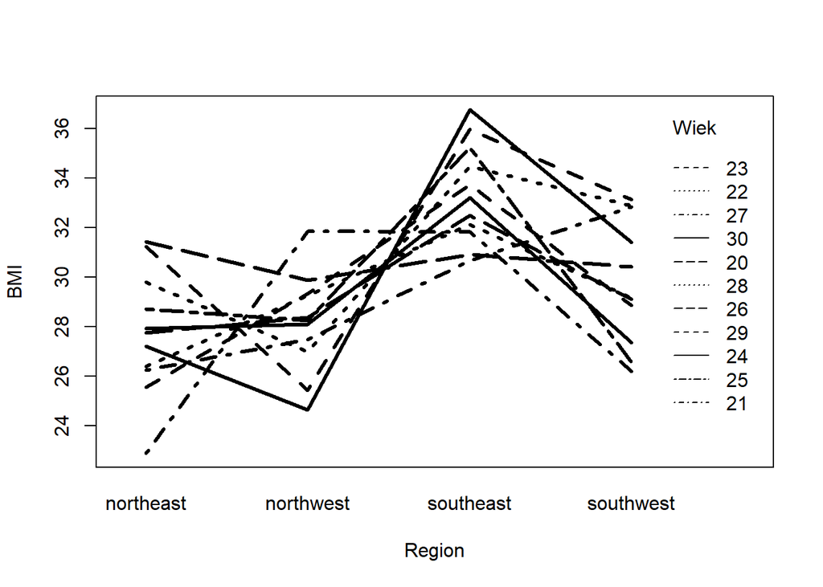

```r
interaction.plot(data$region, data$age, data$bmi,
                 ylab= "BMI", xlab="Region",
                 trace.label="Wiek",
                 lwd=3)
```

### Analiza normalności

Po wykonaniu tego kroku mogę przystąpić do analizy normalności w podgrupach. Jak widzimy, każda podgrupa posiada p-value na poziomie minimum 0.05, co dowodzi, że dane spełniają czwarte założenie ANOVA o normalności obserwacji w podgrupach.

```r
tapply(data$bmi, data$region, jarque.bera.test)
```

```
## $northeast
##
##  Jarque Bera Test
##
## data:  X[[i]]
## X-squared = 2.0112, df = 2, p-value = 0.3658
##
##
## $northwest
##
##  Jarque Bera Test
##
## data:  X[[i]]
## X-squared = 1.7151, df = 2, p-value = 0.4242
##
##
## $southeast
##
##  Jarque Bera Test
##
## data:  X[[i]]
## X-squared = 5.0951, df = 2, p-value = 0.07827
##
##
## $southwest
##
##  Jarque Bera Test
##
## data:  X[[i]]
## X-squared = 1.1947, df = 2, p-value = 0.5503
```

```r
tapply(data$bmi, data$age, jarque.bera.test)
```

```
## $`20`
##
##  Jarque Bera Test
##
## data:  X[[i]]
## X-squared = 0.01112, df = 2, p-value = 0.9945
##
##
## $`21`
##
##  Jarque Bera Test
##
## data:  X[[i]]
## X-squared = 1.3709, df = 2, p-value = 0.5039
##
##
## $`22`
##
##  Jarque Bera Test
##
## data:  X[[i]]
## X-squared = 5.588, df = 2, p-value = 0.06118
##
##
## $`23`
##
##  Jarque Bera Test
##
## data:  X[[i]]
## X-squared = 0.61338, df = 2, p-value = 0.7359
##
##
## $`24`
##
##  Jarque Bera Test
##
## data:  X[[i]]
## X-squared = 0.96545, df = 2, p-value = 0.6171
##
##
```

[output cut: 31 more lines]

```
##
## $`29`
##
##  Jarque Bera Test
##
## data:  X[[i]]
## X-squared = 0.95866, df = 2, p-value = 0.6192
##
##
## $`30`
##
##  Jarque Bera Test
##
## data:  X[[i]]
## X-squared = 1.3548, df = 2, p-value = 0.5079
```

```r
tapply(data$bmi, data$reg_age, jarque.bera.test)
```

```
## $northeast_20
##
##  Jarque Bera Test
##
## data:  X[[i]]
## X-squared = 2.5975, df = 2, p-value = 0.2729
##
##
## $northeast_21
##
##  Jarque Bera Test
##
## data:  X[[i]]
## X-squared = 0.44227, df = 2, p-value = 0.8016
##
##
## $northeast_22
##
##  Jarque Bera Test
##
## data:  X[[i]]
## X-squared = 0.23116, df = 2, p-value = 0.8908
##
##
## $northeast_23
##
##  Jarque Bera Test
##
## data:  X[[i]]
## X-squared = 0.58125, df = 2, p-value = 0.7478
##
##
## $northeast_24
##
##  Jarque Bera Test
##
## data:  X[[i]]
## X-squared = 0.33731, df = 2, p-value = 0.8448
##
##
```

[output cut: 295 more lines]

```
##
## $southwest_29
##
##  Jarque Bera Test
##
## data:  X[[i]]
## X-squared = 0.9294, df = 2, p-value = 0.6283
##
##
## $southwest_30
##
##  Jarque Bera Test
##
## data:  X[[i]]
## X-squared = 0.22134, df = 2, p-value = 0.8952
```

Normalność rozkładu danych możemy zwizualizować za pomocą histogramów:

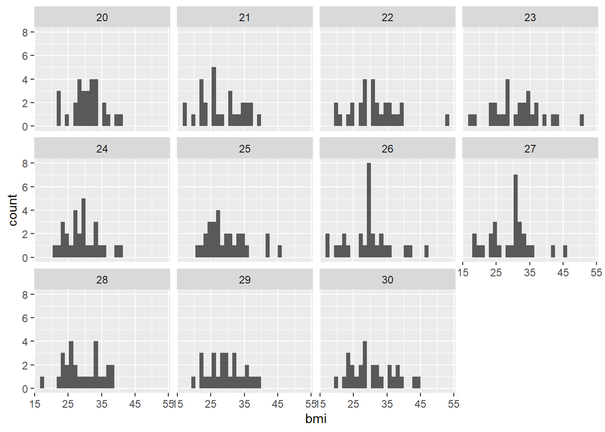

```r
ggplot(data) + geom_histogram(aes(x = bmi)) + facet_wrap(~age)
```

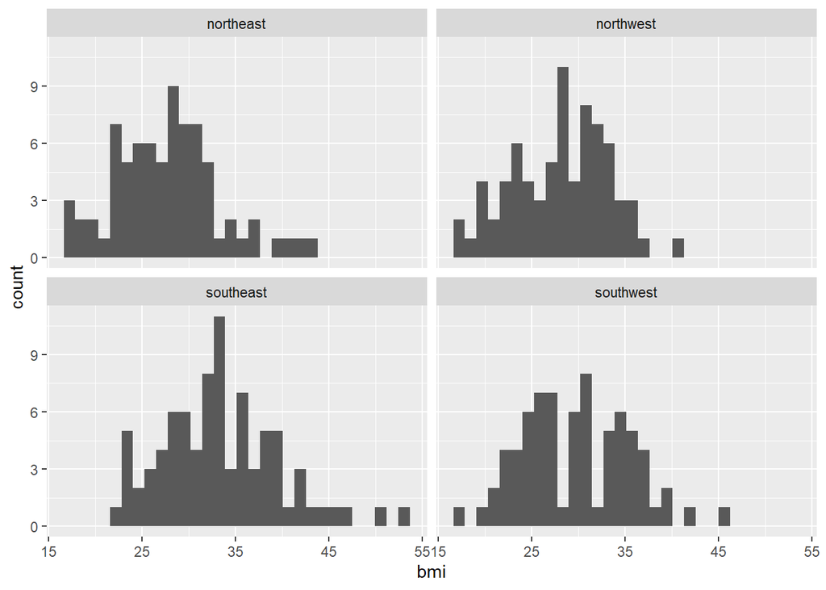

```r
ggplot(data) + geom_histogram(aes(x = bmi)) + facet_wrap(~region)
```

W inny sposób możemy spojrzeć na te same dane za pomocą wykresów pudełkowych, których charakterystyczny kształt również wskazuje na rozkład normalny podgrup:

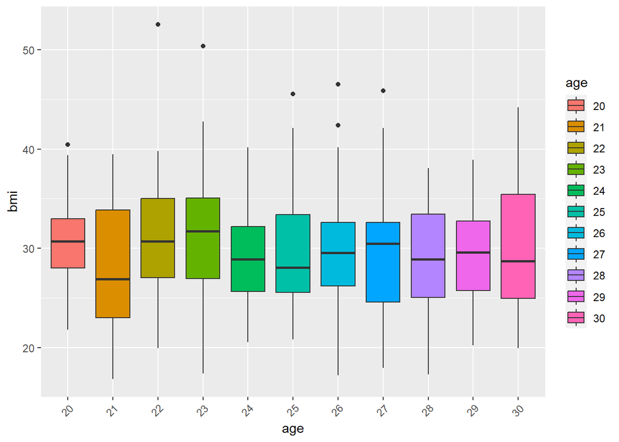

```r
ggplot(data, aes(x=age, y=bmi)) +
  geom_boxplot(aes(fill=age)) +
  theme(axis.text.x = element_text(angle = 45, hjust = 1))
```

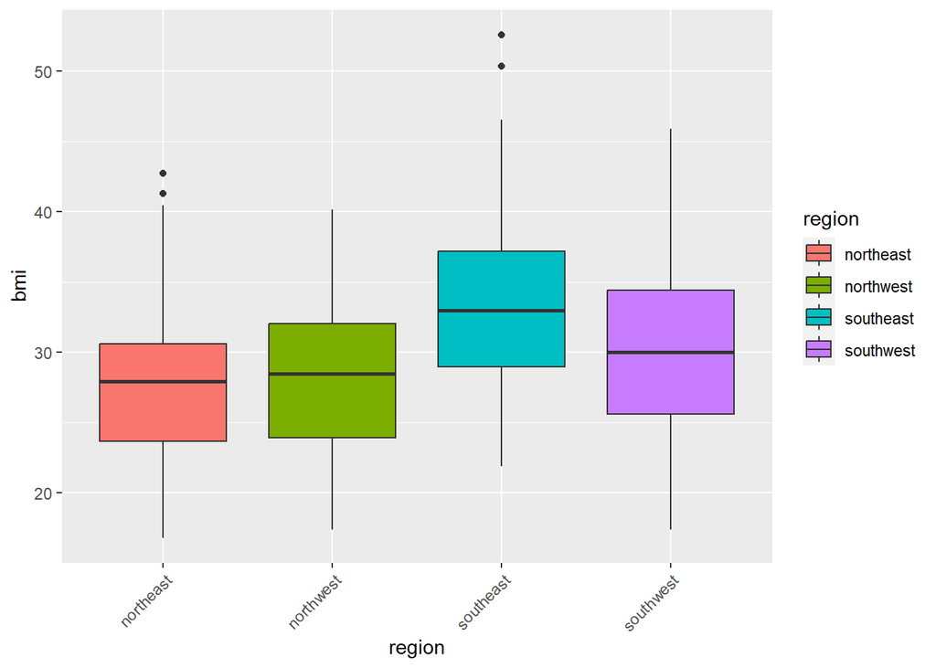

```r
ggplot(data, aes(x=region, y=bmi)) +
  geom_boxplot(aes(fill=region)) +
  theme(axis.text.x = element_text(angle = 45, hjust = 1))
```

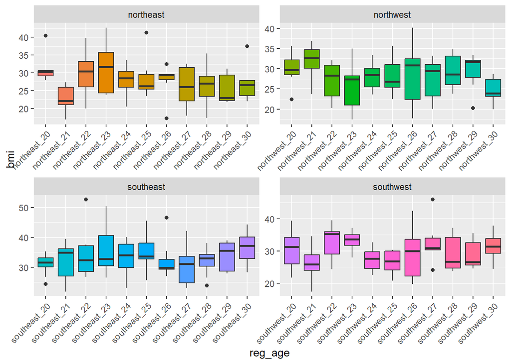

```r
ggplot(data, aes(x=reg_age, y=bmi)) +
  geom_boxplot(aes(fill=reg_age)) +
  theme(axis.text.x = element_text(angle = 45, hjust = 1)) +
  theme(legend.position = "none") +
  facet_wrap( ~ region, scales="free")
```

### Analiza wariancji

Przed przystąpieniem do samej analizy, należy także sprawdzić równość wariancji w podgrupach. Wartość p-value wskazuje na spełnienie piątego założenia klasycznej metody ANOVA o homogeniczności wariancji w podgrupach.

W przypadku każdej zmiennej test Bartletta zwraca p-value na poziomie większym od wartości krytycznej 0.05, a więc możemy przyjąć hipotezę zerową o równości wariancji w podgrupach.

```r
bartlett.test(bmi ~ age, data=data)
```

```
##
##  Bartlett test of homogeneity of variances
##
## data:  bmi by age
## Bartlett's K-squared = 11.975, df = 10, p-value = 0.2867
```

```r
bartlett.test(bmi ~ region, data=data)
```

```
##
##  Bartlett test of homogeneity of variances
##
## data:  bmi by region
## Bartlett's K-squared = 3.3369, df = 3, p-value = 0.3425
```

```r
bartlett.test(bmi ~ reg_age, data=data)
```

```
##
##  Bartlett test of homogeneity of variances
##
## data:  bmi by reg_age
## Bartlett's K-squared = 31.37, df = 43, p-value = 0.9058
```

### ANOVA jednoczynnikowa

W tym kroku możemy już przystąpić do analizy wariancji ANOVA z pomocą funkcji aov(). Poniższy kod pozwala na przeprowadzenie analizy jednoczynnikowej i jej podsumowanie.

Wynik wskazuje na silny związek średniego BMI w grupach w zależności od regionu. Z kolei zmienna określająca wiek z bardzo wysokim p-value okazuje się byc mniej istotna, tak jak zakładaliśmy na poziomie analizy interakcji.

```r
one_way <- aov(bmi ~ age + region, data = data)
summary(one_way)
```

```
##              Df Sum Sq Mean Sq F value   Pr(>F)
## age          10    255    25.5   0.774    0.654
## region        3   1558   519.2  15.750 1.62e-09 ***
## Residuals   291   9593    33.0
## ---
## Signif. codes:  0 '***' 0.001 '**' 0.01 '*' 0.05 '.' 0.1 ' ' 1
```

### ANOVA dwuczynnikowa

Analiza dwuczynnikowa potwierdza powyższy wniosek o istotności zmiennej określającej region w średniej wartości BMI w podgrupach i jednocześnie niewielką istotność zmiennej określającej wiek.

Okazuje się także, że połączenie obu tych zmiennych nie wpływa w istotny sposób na średnie BMI. Oznacza to brak efektu interakcji (łącznego wpływu działania zmiennych określających wiek oraz region).

```r
two_way <- aov(bmi ~ age * region, data = data)
summary(two_way)
```

```
##              Df Sum Sq Mean Sq F value   Pr(>F)
## age          10    255    25.5   0.793    0.635
## region        3   1558   519.2  16.146 1.17e-09 ***
## age:region   30   1200    40.0   1.244    0.186
## Residuals   261   8393    32.2
## ---
## Signif. codes:  0 '***' 0.001 '**' 0.01 '*' 0.05 '.' 0.1 ' ' 1
```

### Analiza post-hoc

Z analizy post-hoc wynika, że poszczególne grupy wiekowe nie różnią się znacząco BMI. Najistotniejsza różnica występuje miedzy grupą 23 i 21-latków, z czego 23 latkowie mają średnio większe MBI o 3.19.

```r
TukeyHSD(one_way)
```

```
##   Tukey multiple comparisons of means
##     95% family-wise confidence level
##
## Fit: aov(formula = bmi ~ age + region, data = data)
##
## $age
##               diff       lwr      upr     p adj
## 21-20 -2.447044335 -7.382700 2.488611 0.8776858
## 22-20  0.454919951 -4.480736 5.390576 0.9999999
## 23-20  0.749648787 -4.232292 5.731590 0.9999930
## 24-20 -1.490080049 -6.425736 3.445576 0.9963282
## 25-20 -0.938830049 -5.874486 3.996826 0.9999366
## 26-20 -1.203830049 -6.139486 3.731826 0.9994009
## 27-20 -1.299187192 -6.234843 3.636469 0.9988382
## 28-20 -1.295721584 -6.277663 3.686219 0.9989522
## 29-20 -1.249610473 -6.231551 3.732331 0.9992347
## 30-20 -0.075166028 -5.057107 4.906775 1.0000000
## 22-21  2.901964286 -2.076798 7.880727 0.7227064
## 23-21  3.196693122 -1.827958 8.221344 0.6038567
## 24-21  0.956964286 -4.021798 5.935727 0.9999302
## 25-21  1.508214286 -3.470548 6.486977 0.9962247
## 26-21  1.243214286 -3.735548 6.221977 0.9992641
## 27-21  1.147857143 -3.830906 6.126620 0.9996359
## 28-21  1.151322751 -3.873328 6.175974 0.9996554
## 29-21  1.197433862 -3.827217 6.222085 0.9995116
## 30-21  2.371878307 -2.652773 7.396529 0.9080840
## 23-22  0.294728836 -4.729922 5.319380 1.0000000
## 24-22 -1.945000000 -6.923763 3.033763 0.9734632
## 25-22 -1.393750000 -6.372513 3.585013 0.9980385
## 26-22 -1.658750000 -6.637513 3.320013 0.9919212
## 27-22 -1.754107143 -6.732870 3.224656 0.9875747
## 28-22 -1.750641534 -6.775292 3.274009 0.9885854
## 29-22 -1.704530423 -6.729181 3.320120 0.9907031
## 30-22 -0.530085979 -5.554737 4.494565 0.9999998
## 24-23 -2.239728836 -7.264380 2.784922 0.9354772
## 25-23 -1.688478836 -6.713130 3.336172 0.9913614
## 26-23 -1.953478836 -6.978130 3.071172 0.9743577
## 27-23 -2.048835979 -7.073487 2.975815 0.9642109
## 28-23 -2.045370370 -7.115494 3.024753 0.9667577
## 29-23 -1.999259259 -7.069383 3.070865 0.9716534
```

[output cut: 16 more lines]

```
## 28-27  0.003465608 -5.021185 5.028117 1.0000000
## 29-27  0.049576720 -4.975074 5.074228 1.0000000
## 30-27  1.224021164 -3.800630 6.248672 0.9994074
## 29-28  0.046111111 -5.024013 5.116235 1.0000000
## 30-28  1.220555556 -3.849568 6.290679 0.9994661
## 30-29  1.174444444 -3.895679 6.244568 0.9996203
##
## $region
##                          diff        lwr       upr     p adj
## northwest-northeast  0.464484 -1.9663708  2.895339 0.9604446
## southeast-northeast  5.612961  3.2493756  7.976546 0.0000000
## southwest-northeast  2.009160 -0.4300614  4.448381 0.1465571
## southeast-northwest  5.148477  2.7765170  7.520436 0.0000003
## southwest-northwest  1.544676 -0.9026611  3.992013 0.3628661
## southwest-southeast -3.603801 -5.9843339 -1.223268 0.0006569
```

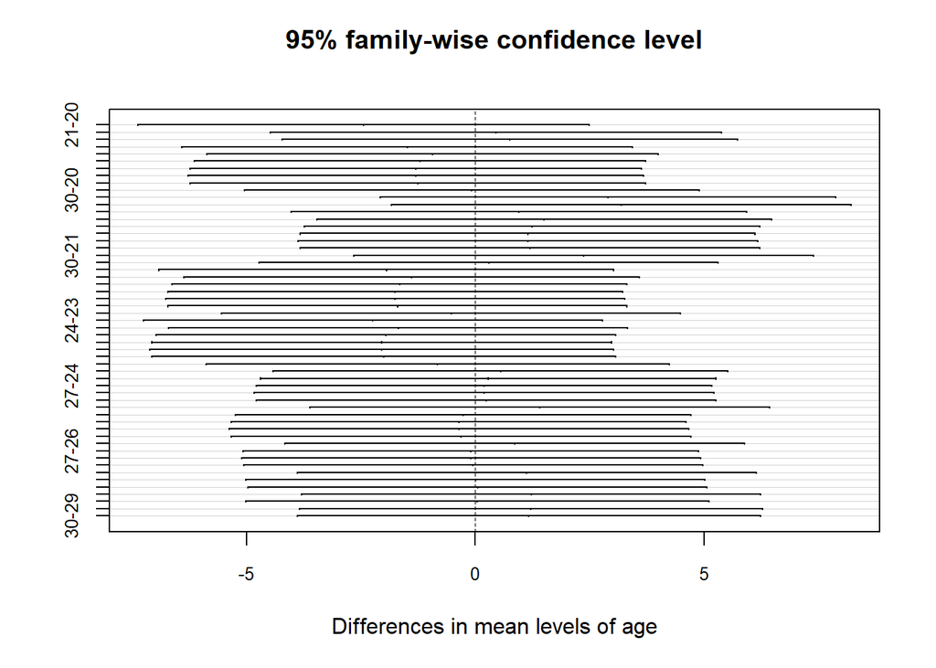

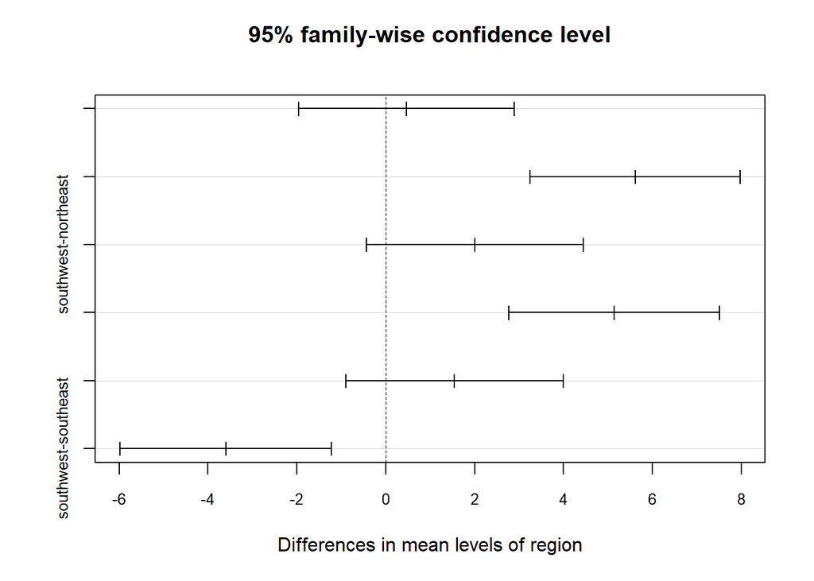

```r
plot(TukeyHSD(one_way), cex.axis = 0.8)
```